# Metro SP Phase II Task B

## Model Estimation

### 6/22/2017

# Task A

Three weights from Task A to be tested in Task B:
- b. county x htype2 (SF, MF) x tenure x age_group5 x hhinc2
- d. county x htype2 x tenure x age_group3 x hhinc4a
- e. county x htype2 x tenure x age_group5 x hhinc4b

Replicate results using Roger's and Sonny's weights
- rbc
- sc

# Task B

- B.1 Estimation by Sources and Evaluation of Sampling Bias
- B.2 Estimate and Compare Models county vs. MSA
- B.3 Mixed Logit Model
- B.4 Explore and test schemes for market segmentation
- B.5 Combine SP and RP data
- B.6 Neighborhood Choice

# Coefficients by weighting schemes

|  | wgt.none | wgt.b | wgt.d | wgt.e | wgt.sc | wgt.rbc |
| --- | --- | --- | --- | --- | --- | --- |
|  | (1) | (2) | (3) | (4) | (5) | (6) |
| 1:(intercept) | 0.088*** | 0.083*** | 0.112*** | 0.088*** | 0.074*** | 0.088*** |
|  | (0.012) | (0.012) | (0.012) | (0.012) | (0.012) | (0.012) |
| price | -0.001*** | -0.001*** | -0.001*** | -0.001*** | -0.001*** | -0.001*** |
|  | (0.00003) | (0.00003) | (0.00003) | (0.00003) | (0.00003) | (0.00003) |
| own | -0.100*** | -0.356*** | -0.356*** | -0.352*** | -0.290*** | -0.225*** |
|  | (0.038) | (0.038) | (0.038) | (0.038) | (0.038) | (0.038) |
| commute_time | -0.017*** | -0.021*** | -0.020*** | -0.020*** | -0.020*** | -0.019*** |
|  | (0.001) | (0.001) | (0.001) | (0.001) | (0.001) | (0.001) |
| size | 0.0002*** | 0.001*** | 0.001*** | 0.001*** | 0.0005*** | 0.0004*** |
|  | (0.00004) | (0.00005) | (0.00004) | (0.00005) | (0.00004) | (0.00004) |
| sfd | 0.907*** | 0.633*** | 0.621*** | 0.631*** | 0.751*** | 0.766*** |
|  | (0.033) | (0.033) | (0.033) | (0.033) | (0.033) | (0.033) |
| sfa | 0.616*** | 0.538*** | 0.517*** | 0.521*** | 0.579*** | 0.572*** |
|  | (0.018) | (0.019) | (0.019) | (0.019) | (0.018) | (0.019) |
| N1 | 0.362*** | 0.309*** | 0.288*** | 0.280*** | 0.449*** | 0.414*** |
|  | (0.033) | (0.033) | (0.033) | (0.033) | (0.033) | (0.033) |
| N2 | 0.569*** | 0.518*** | 0.530*** | 0.520*** | 0.597*** | 0.592*** |
|  | (0.023) | (0.023) | (0.023) | (0.023) | (0.023) | (0.023) |
| N3 | 0.115*** | 0.156*** | 0.161*** | 0.150*** | 0.122*** | 0.121*** |
|  | (0.024) | (0.024) | (0.024) | (0.024) | (0.024) | (0.024) |
| price:own | 0.0005*** | 0.001*** | 0.001*** | 0.001*** | 0.001*** | 0.001*** |
|  | (0.00002) | (0.00002) | (0.00002) | (0.00002) | (0.00002) | (0.00002) |
| Observations | 58,825 | 57,871 | 57,826 | 57,691 | 58,825 | 57,988 |
| R<sup>2</sup> | 0.118 | 0.126 | 0.127 | 0.126 | 0.124 | 0.121 |
| Log Likelihood | -35,948.500 | -35,034.130 | -34,967.650 | -34,924.510 | -35,701.800 | -35,326.410 |
| *Note:* | *p<0.1; **p<0.05; ***p<0.01 |  |  |  |  |  |

# WTPs by weighting schemes

| wgtstr | n | Rent $/sqft | Rent $/min | Own $/sqft | Own $/min |
| --- | --- | --- | --- | --- | --- |
| wgt.none | 58825 | 0.218 | 16.228 | 0.391 | 29.096 |
| wgt.b | 57871 | 0.446 | 15.845 | 0.873 | 30.973 |
| wgt.d | 57826 | 0.443 | 15.577 | 0.863 | 30.320 |
| wgt.e | 57691 | 0.430 | 15.324 | 0.826 | 29.444 |
| wgt.sc | 58825 | 0.364 | 15.711 | 0.676 | 29.150 |
| wgt.rbc | 57988 | 0.361 | 16.580 | 0.665 | 30.545 |

# WTPs by weighting schemes

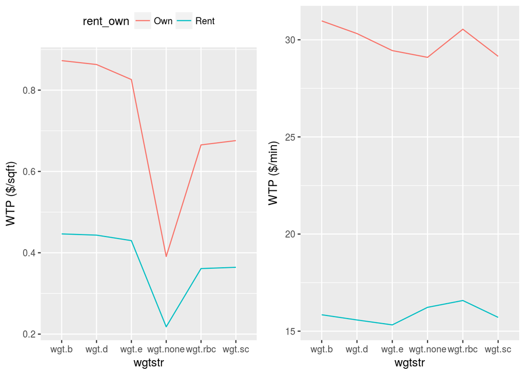

# Task B.1 Estimation by Sources and Evaluation of Sampling Bias

# Coefficients by Sources (no weights)

**Coefficients by Sources (no weights)**

|  | Combined | Recruited | Panel | Opt-in |
| --- | --- | --- | --- | --- |
|  | (1) | (2) | (3) | (4) |
| 1:(intercept) | 0.088*** | 0.105*** | 0.026 | 0.090*** |
|  | (0.012) | (0.022) | (0.035) | (0.017) |
| price | -0.001*** | -0.001*** | -0.001*** | -0.001*** |
|  | (0.00003) | (0.00005) | (0.0001) | (0.00004) |
| own | -0.100*** | 0.050 | -0.315*** | -0.120** |
|  | (0.038) | (0.073) | (0.099) | (0.050) |
| commute_time | -0.017*** | -0.015*** | -0.014*** | -0.018*** |
|  | (0.001) | (0.001) | (0.002) | (0.001) |
| size | 0.0002*** | 0.0002*** | 0.0005*** | 0.0001** |
|  | (0.00004) | (0.0001) | (0.0001) | (0.0001) |
| sfd | 0.907*** | 1.014*** | 0.798*** | 0.900*** |
|  | (0.033) | (0.061) | (0.094) | (0.044) |
| sfa | 0.616*** | 0.643*** | 0.640*** | 0.607*** |
|  | (0.018) | (0.034) | (0.052) | (0.025) |
| N1 | 0.362*** | 0.243*** | 0.116 | 0.481*** |
|  | (0.033) | (0.060) | (0.093) | (0.044) |
| N2 | 0.569*** | 0.506*** | 0.210*** | 0.691*** |
|  | (0.023) | (0.041) | (0.063) | (0.030) |
| N3 | 0.115*** | 0.143*** | 0.223*** | 0.078** |
|  | (0.024) | (0.043) | (0.066) | (0.032) |
| price:own | 0.0005*** | 0.0004*** | 0.001*** | 0.0005*** |
|  | (0.00002) | (0.00004) | (0.0001) | (0.00003) |
| Observations | 58,825 | 18,207 | 7,368 | 33,250 |
| R<sup>2</sup> | 0.118 | 0.120 | 0.132 | 0.122 |
| Log Likelihood | -35,948.500 | -11,110.900 | -4,430.548 | -20,208.860 |
| *Note:* | *p<0.1; **p<0.05; ***p<0.01 |  |  |  |

# WTPs by Sources (no weights)

| segment | n | Rent $/sqft | Rent $/min | Own $/sqft | Own $/min |
| --- | --- | --- | --- | --- | --- |
| Combined | 58825 | 0.218 | 16.228 | 0.391 | 29.096 |
| Recruited | 18207 | 0.248 | 17.745 | 0.445 | 31.882 |
| Panel | 7368 | 0.319 | 9.796 | 0.581 | 17.849 |
| Opt-in | 33250 | 0.139 | 16.427 | 0.243 | 28.743 |

# WTPs by Sources (no weights)

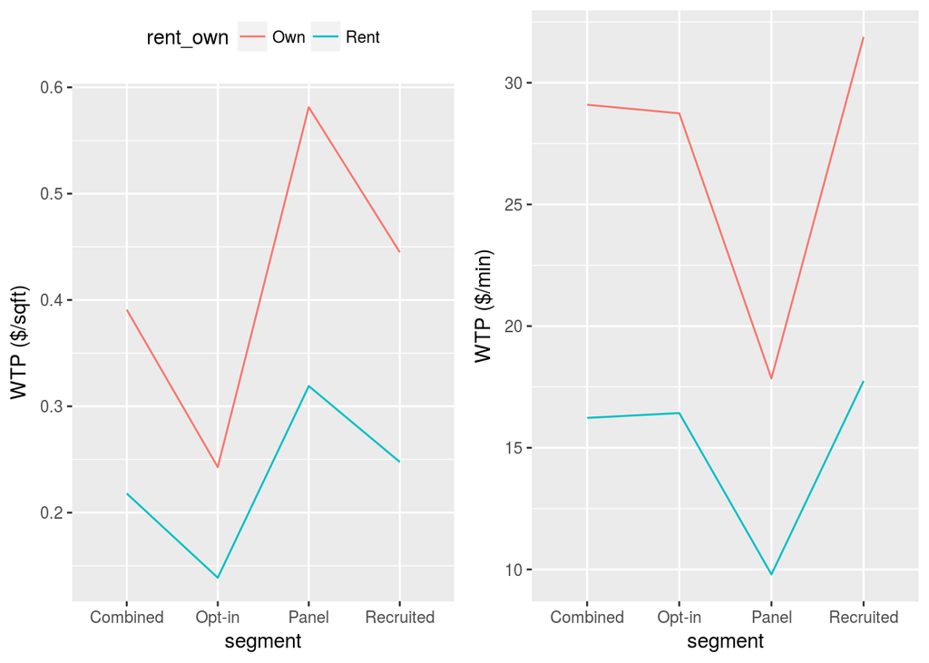

# WTPs by Sources (no weights)

There is sizable difference in the WTPs across different sources when weights are not used in estimation:

- Surveyees from the Panel have the highest WTP for spaces (`$`/sqft) and lowest WTP for travel time saving (`$`/minute of commuting time);
- Surveyees in the Opt-in sample have the lowest WTP for spaces (`$`/sqft);
- Recruited surveyees have the highest WTP for travel time saving (`$`/minute of commuting time).

# Coefficients by Sources (weights=wgt.b)

|  | Combined | Recruited | Panel | Opt-in |
| --- | --- | --- | --- | --- |
|  | (1) | (2) | (3) | (4) |
| 1:(intercept) | 0.083*** | 0.132*** | 0.066* | 0.072*** |
|  | (0.012) | (0.023) | (0.035) | (0.017) |
| price | -0.001*** | -0.001*** | -0.002*** | -0.001*** |
|  | (0.00003) | (0.0001) | (0.0001) | (0.00004) |
| own | -0.356*** | -0.034 | -0.459*** | -0.422*** |
|  | (0.038) | (0.074) | (0.100) | (0.050) |
| commute_time | -0.021*** | -0.019*** | -0.019*** | -0.021*** |
|  | (0.001) | (0.001) | (0.002) | (0.001) |
| size | 0.001*** | 0.0005*** | 0.001*** | 0.001*** |
|  | (0.00005) | (0.0001) | (0.0001) | (0.0001) |
| sfd | 0.633*** | 0.904*** | 0.540*** | 0.602*** |
|  | (0.033) | (0.063) | (0.094) | (0.043) |
| sfa | 0.538*** | 0.592*** | 0.537*** | 0.530*** |
|  | (0.019) | (0.034) | (0.052) | (0.025) |
| N1 | 0.309*** | 0.335*** | 0.002 | 0.472*** |
|  | (0.033) | (0.062) | (0.095) | (0.044) |
| N2 | 0.518*** | 0.543*** | 0.251*** | 0.666*** |
|  | (0.023) | (0.042) | (0.064) | (0.030) |
| N3 | 0.156*** | 0.161*** | 0.268*** | 0.090*** |
|  | (0.024) | (0.044) | (0.068) | (0.032) |
| price:own | 0.001*** | 0.0005*** | 0.001*** | 0.001*** |
|  | (0.00002) | (0.00004) | (0.0001) | (0.00003) |
| Observations | 57,871 | 17,379 | 7,287 | 33,205 |
| R<sup>2</sup> | 0.126 | 0.126 | 0.149 | 0.127 |
| Log Likelihood | -35,034.130 | -10,530.190 | -4,296.891 | -20,079.160 |
| *Note:* | *p<0.1; **p<0.05; ***p<0.01 |  |  |  |

# WTPs by Sources (weights=wgt.b)

| segment | n | Rent $/sqft | Rent $/min | Own $/sqft | Own $/min |
| --- | --- | --- | --- | --- | --- |
| Combined | 57871 | 0.446 | 15.845 | 0.873 | 30.973 |
| Recruited | 17379 | 0.443 | 18.059 | 0.833 | 33.949 |
| Panel | 7287 | 0.422 | 11.606 | 0.800 | 22.023 |
| Opt-in | 33205 | 0.393 | 16.382 | 0.763 | 31.757 |

# WTPs by Sources (weights=wgt.b)

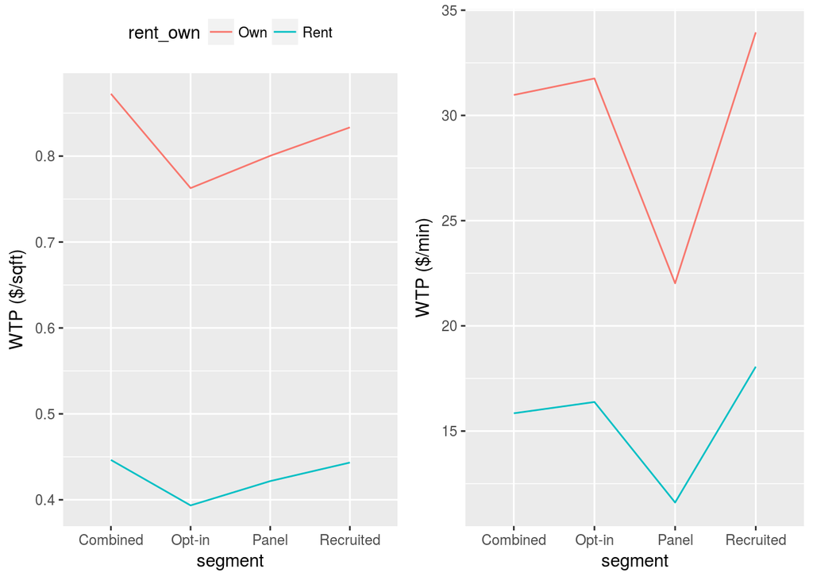

# WTPs by Sources (weights=wgt.b)

# Task B.2 Estimate and Compare Models county vs. MSA

# Coefficients by County (weights=wgt.b)

|  | wgt.b | wgt.b | wgt.b | wgt.b | wgt.b |
| --- | --- | --- | --- | --- | --- |
|  | (1) | (2) | (3) | (4) | (5) |
| 1:(intercept) | 0.083*** | 0.088*** | 0.087*** | 0.070** | 0.089 |
|  | (0.012) | (0.018) | (0.022) | (0.030) | (0.067) |
| price | -0.001*** | -0.001*** | -0.001*** | -0.001*** | -0.001*** |
|  | (0.00003) | (0.00004) | (0.0001) | (0.0001) | (0.0002) |
| own | -0.356*** | -0.316*** | -0.334*** | -0.409*** | -0.201 |
|  | (0.038) | (0.053) | (0.074) | (0.102) | (0.190) |
| commute_time | -0.021*** | -0.020*** | -0.020*** | -0.017*** | -0.016*** |
|  | (0.001) | (0.001) | (0.001) | (0.002) | (0.004) |
| size | 0.001*** | 0.0002*** | 0.001*** | 0.001*** | 0.0004* |
|  | (0.00005) | (0.0001) | (0.0001) | (0.0001) | (0.0002) |
| sfd | 0.633*** | 0.683*** | 0.850*** | 0.738*** | 0.750*** |
|  | (0.033) | (0.046) | (0.065) | (0.090) | (0.182) |
| sfa | 0.538*** | 0.542*** | 0.618*** | 0.592*** | 0.582*** |
|  | (0.019) | (0.027) | (0.034) | (0.048) | (0.099) |
| N1 | 0.309*** | 0.933*** | 0.177*** | -0.351*** | -0.153 |
|  | (0.033) | (0.048) | (0.062) | (0.086) | (0.188) |
| N2 | 0.518*** | 1.079*** | 0.305*** | -0.121** | 0.355*** |
|  | (0.023) | (0.034) | (0.042) | (0.056) | (0.124) |
| N3 | 0.156*** | 0.084** | 0.251*** | -0.011 | 0.316** |
|  | (0.024) | (0.035) | (0.044) | (0.061) | (0.128) |
| price:own | 0.001*** | 0.001*** | 0.001*** | 0.001*** | 0.001*** |
|  | (0.00002) | (0.00003) | (0.00004) | (0.0001) | (0.0001) |
| Observations | 57,871 | 27,964 | 18,362 | 9,497 | 2,048 |
| R<sup>2</sup> | 0.126 | 0.143 | 0.155 | 0.140 | 0.152 |
| Log Likelihood | -35,034.130 | -16,550.890 | -10,753.380 | -5,654.951 | -1,201.539 |
| *Note:* | *p<0.1; **p<0.05; ***p<0.01 |  |  |  |  |

# WTPs by County (weights=wgt.b)

| segment | n | Rent $/sqft | Rent $/min | Own $/sqft | Own $/min |
| --- | --- | --- | --- | --- | --- |
| Combined | 57871 | 0.446 | 15.845 | 0.873 | 30.973 |
| Multnh | 27964 | 0.140 | 15.791 | 0.255 | 28.637 |
| Washgn | 18362 | 0.454 | 13.913 | 0.815 | 25.008 |
| Clackms | 9497 | 0.482 | 13.424 | 1.041 | 28.990 |
| Clark | 2048 | 0.315 | 11.453 | 0.598 | 21.730 |

# WTPs by County (weights=wgt.b)

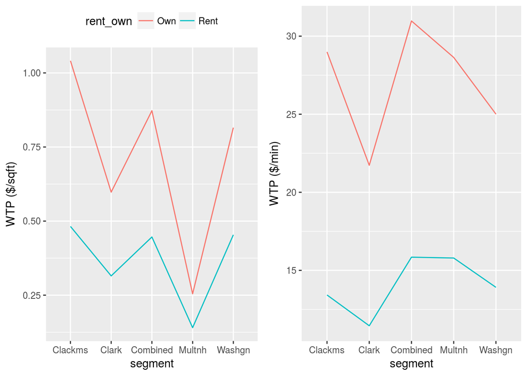

# WTPs by County (weights=wgt.b)

# B.3 Mixed Logit Model

# Coefficients of the mixed logit model (weights=wgt.b)

| 1:(intercept) | 1.085 | 0.014 | 5.752 | < 0.001 |
| --- | --- | --- | --- | --- |
| price | 0.998 | 0 | -43.99 | < 0.001 |
| own | 0.661 | 0.041 | -10.176 | < 0.001 |
| sfd | 2.33 | 0.042 | 20.267 | < 0.001 |
| sfa | 1.947 | 0.022 | 30.096 | < 0.001 |
| N1 | 1.497 | 0.038 | 10.583 | < 0.001 |
| N2 | 1.843 | 0.026 | 23.639 | < 0.001 |
| N3 | 1.169 | 0.027 | 5.725 | < 0.001 |
| price:own | 1.001 | 0 | 31.299 | < 0.001 |
| commute_time | 0.977 | 0.001 | -25.399 | < 0.001 |
| size | 1.001 | 0 | 8.248 | < 0.001 |
| sd.commute_time | 1.018 | 0.001 | 24.657 | < 0.001 |
| sd.size | 1.002 | 0 | 47.212 | < 0.001 |
| df | 57871 |  | logLikehood | -33312.0928219 |

# Coefficients of the fixed effect logit model (weights=wgt.b)

| 1:(intercept) | 1.087 | 0.012 | 6.735 | < 0.001 |
| --- | --- | --- | --- | --- |
| price | 0.999 | 0 | -44.925 | < 0.001 |
| own | 0.701 | 0.038 | -9.332 | < 0.001 |
| commute_time | 0.98 | 0.001 | -29.857 | < 0.001 |
| size | 1.001 | 0 | 12.918 | < 0.001 |
| sfd | 1.883 | 0.033 | 19.103 | < 0.001 |
| sfa | 1.712 | 0.019 | 28.921 | < 0.001 |
| N1 | 1.362 | 0.033 | 9.255 | < 0.001 |
| N2 | 1.678 | 0.023 | 22.652 | < 0.001 |
| N3 | 1.169 | 0.024 | 6.482 | < 0.001 |
| price:own | 1.001 | 0 | 30.417 | < 0.001 |
| df | 57871 |  | logLikehood | -35034.1307182 |

# Fixed effect vs Mixed Logit Model

A likelihood ratio test indicates a significant improvement in model goodness-of-fit (Chi-square=3444.1, df=2, p<0.001) of the mixed logit model and thus there is significant correlation between responses of the same surveyee such that the mixed logit model is a better model for the SP data.

```
## Likelihood ratio test
##
## Model 1: choice ~ price * own + commute_time + size + sfd + sfa + N1 +
##     N2 + N3 | 1
## Model 2: choice ~ price * own + commute_time + size + sfd + sfa + N1 +
##     N2 + N3 | 1
##   #Df LogLik Df  Chisq Pr(>Chisq)
## 1  11 -35034
## 2  13 -33312  2 3444.1  < 2.2e-16 ***
## ---
## Signif. codes:  0 '***' 0.001 '**' 0.01 '*' 0.05 '.' 0.1 ' ' 1
```

# WTP Fixed effect vs Mixed Logit Model

Mean WTPs from the mixed logit model (mxl) is lower than those from the multinomial logit model (mnl).

| wgtstr | modelstr | n | Rent $/sqft | Rent $/min | Own $/sqft | Own $/min |
| --- | --- | --- | --- | --- | --- | --- |
| wgt.b | mxl | 57871 | 0.320 | 13.728 | 0.596 | 25.554 |
| wgt.b | mnl | 57871 | 0.446 | 15.845 | 0.873 | 30.973 |

# B.4 Explore and test schemes for market segmentation

# Coefficients by Income Group (weights=wgt.b)

|  | Combined | 25k+ | <25k |
| --- | --- | --- | --- |
|  | (1) | (2) | (3) |
| 1:(intercept) | 0.083*** | 0.081*** | 0.096** |
|  | (0.012) | (0.013) | (0.045) |
| price | -0.001*** | -0.001*** | -0.002*** |
|  | (0.00003) | (0.00003) | (0.0001) |
| own | -0.356*** | -0.166*** | -0.849*** |
|  | (0.038) | (0.041) | (0.118) |
| commute_time | -0.021*** | -0.018*** | -0.024*** |
|  | (0.001) | (0.001) | (0.003) |
| size | 0.001*** | 0.0004*** | 0.001*** |
|  | (0.00005) | (0.00005) | (0.0002) |
| sfd | 0.633*** | 0.850*** | 0.134 |
|  | (0.033) | (0.035) | (0.110) |
| sfa | 0.538*** | 0.616*** | 0.292*** |
|  | (0.019) | (0.020) | (0.066) |
| N1 | 0.309*** | 0.333*** | 0.318*** |
|  | (0.033) | (0.035) | (0.118) |
| N2 | 0.518*** | 0.533*** | 0.486*** |
|  | (0.023) | (0.024) | (0.081) |
| N3 | 0.156*** | 0.141*** | 0.195** |
|  | (0.024) | (0.025) | (0.084) |
| price:own | 0.001*** | 0.001*** | 0.001*** |
|  | (0.00002) | (0.00002) | (0.0001) |
| Observations | 57,871 | 53,340 | 4,531 |
| R<sup>2</sup> | 0.126 | 0.128 | 0.140 |
| Log Likelihood | -35,034.130 | -32,228.570 | -2,672.268 |
| *Note:* | *p<0.1; **p<0.05; ***p<0.01 |  |  |

# WTPs by Income Group (weights=wgt.b)

| segment | n | Rent $/sqft | Rent $/min | Own $/sqft | Own $/min |
| --- | --- | --- | --- | --- | --- |
| Combined | 57871 | 0.446 | 15.845 | 0.873 | 30.973 |
| $25k+ | 53340 | 0.324 | 15.281 | 0.585 | 27.595 |
| <$25k | 4531 | 0.414 | 10.306 | 0.799 | 19.908 |

# WTPs by Income Group (weights=wgt.b)

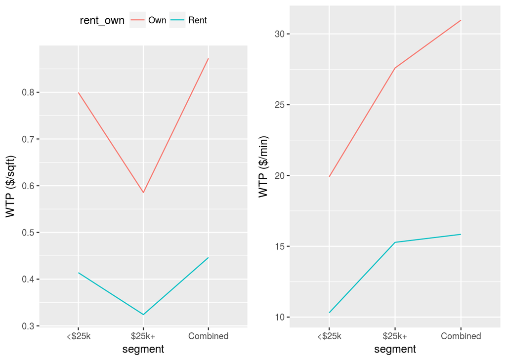

# Coefficients by Tenure Status (weights=wgt.b)

|  | Combined | OWN | RENT |
| --- | --- | --- | --- |
|  | (1) | (2) | (3) |
| 1:(intercept) | 0.083*** | 0.068*** | 0.108*** |
|  | (0.012) | (0.014) | (0.029) |
| price | -0.001*** | -0.001*** | -0.002*** |
|  | (0.00003) | (0.00003) | (0.0001) |
| own | -0.356*** | 0.129** | -0.119 |
|  | (0.038) | (0.050) | (0.082) |
| commute_time | -0.021*** | -0.014*** | -0.019*** |
|  | (0.001) | (0.001) | (0.002) |
| size | 0.001*** | 0.0001** | 0.001*** |
|  | (0.00005) | (0.0001) | (0.0001) |
| sfd | 0.633*** | 0.986*** | 0.595*** |
|  | (0.033) | (0.039) | (0.071) |
| sfa | 0.538*** | 0.604*** | 0.438*** |
|  | (0.019) | (0.021) | (0.042) |
| N1 | 0.309*** | 0.096** | 0.731*** |
|  | (0.033) | (0.038) | (0.076) |
| N2 | 0.518*** | 0.405*** | 0.790*** |
|  | (0.023) | (0.025) | (0.052) |
| N3 | 0.156*** | 0.154*** | 0.190*** |
|  | (0.024) | (0.027) | (0.053) |
| price:own | 0.001*** | 0.0004*** | 0.0004*** |
|  | (0.00002) | (0.00002) | (0.0001) |
| Observations | 57,871 | 45,992 | 11,879 |
| R<sup>2</sup> | 0.126 | 0.121 | 0.158 |
| Log Likelihood | -35,034.130 | -28,019.600 | -6,811.344 |
| *Note:* | *p<0.1; **p<0.05; ***p<0.01 |  |  |

# WTPs by Tenure Status (weights=wgt.b)

| segment | n | Rent $/sqft | Rent $/min | Own $/sqft | Own $/min |
| --- | --- | --- | --- | --- | --- |
| Combined | 57871 | 0.446 | 15.845 | 0.873 | 30.973 |
| OWN | 45992 | 0.137 | 14.798 | 0.223 | 24.117 |
| RENT | 11879 | 0.247 | 8.589 | 0.298 | 10.359 |

# WTPs by Tenure Status (weights=wgt.b)

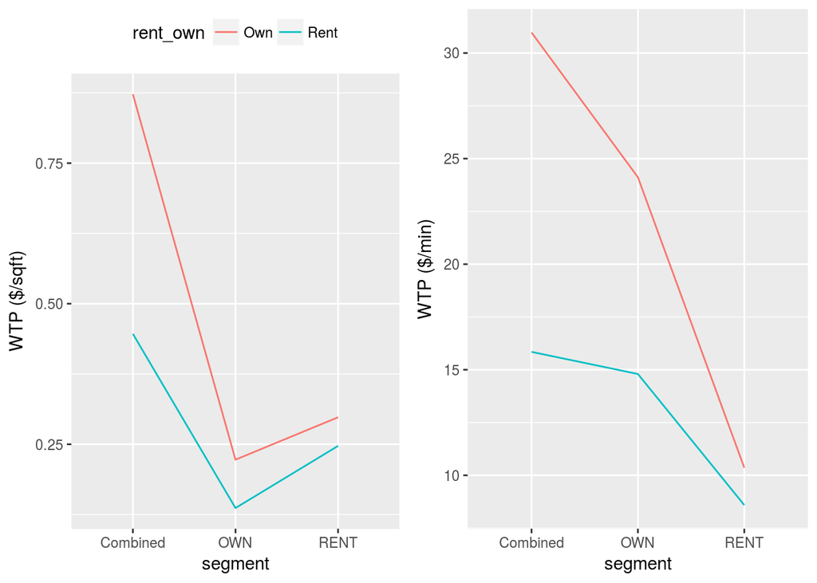

# Coefficients by Current Housing Types (weights=wgt.b)

|  | Combined | SF | MF |
| --- | --- | --- | --- |
|  | (1) | (2) | (3) |
| 1:(intercept) | 0.083*** | 0.070*** | 0.084** |
|  | (0.012) | (0.013) | (0.035) |
| price | -0.001*** | -0.001*** | -0.002*** |
|  | (0.00003) | (0.00003) | (0.0001) |
| own | -0.356*** | 0.040 | -0.235*** |
|  | (0.038) | (0.046) | (0.087) |
| commute_time | -0.021*** | -0.010*** | -0.011*** |
|  | (0.001) | (0.001) | (0.002) |
| size | 0.001*** | -0.0001** | -0.0005** |
|  | (0.00005) | (0.00005) | (0.0002) |
| sfd | 0.633*** | 1.291*** | 0.815*** |
|  | (0.033) | (0.039) | (0.105) |
| sfa | 0.538*** | 0.761*** | 0.451*** |
|  | (0.019) | (0.021) | (0.053) |
| N1 | 0.309*** | 0.132*** | 0.824*** |
|  | (0.033) | (0.037) | (0.090) |
| N2 | 0.518*** | 0.398*** | 0.958*** |
|  | (0.023) | (0.025) | (0.063) |
| N3 | 0.156*** | 0.126*** | 0.234*** |
|  | (0.024) | (0.026) | (0.065) |
| price:own | 0.001*** | 0.0004*** | 0.001*** |
|  | (0.00002) | (0.00002) | (0.0001) |
| Observations | 57,871 | 48,922 | 8,949 |
| R<sup>2</sup> | 0.126 | 0.136 | 0.169 |
| Log Likelihood | -35,034.130 | -29,309.000 | -5,040.319 |
| *Note:* | *p<0.1; **p<0.05; ***p<0.01 |  |  |

# WTPs by Current Housing Types (weights=wgt.b)

| segment | n | Rent $/sqft | Rent $/min | Own $/sqft | Own $/min |
| --- | --- | --- | --- | --- | --- |
| Combined | 57871 | 0.446 | 15.845 | 0.873 | 30.973 |
| SF | 48922 | 0.123 | 9.790 | 0.205 | 16.349 |
| MF | 8949 | 0.198 | 4.627 | 0.251 | 5.871 |

# WTPs by Current Housing Types (weights=wgt.b)

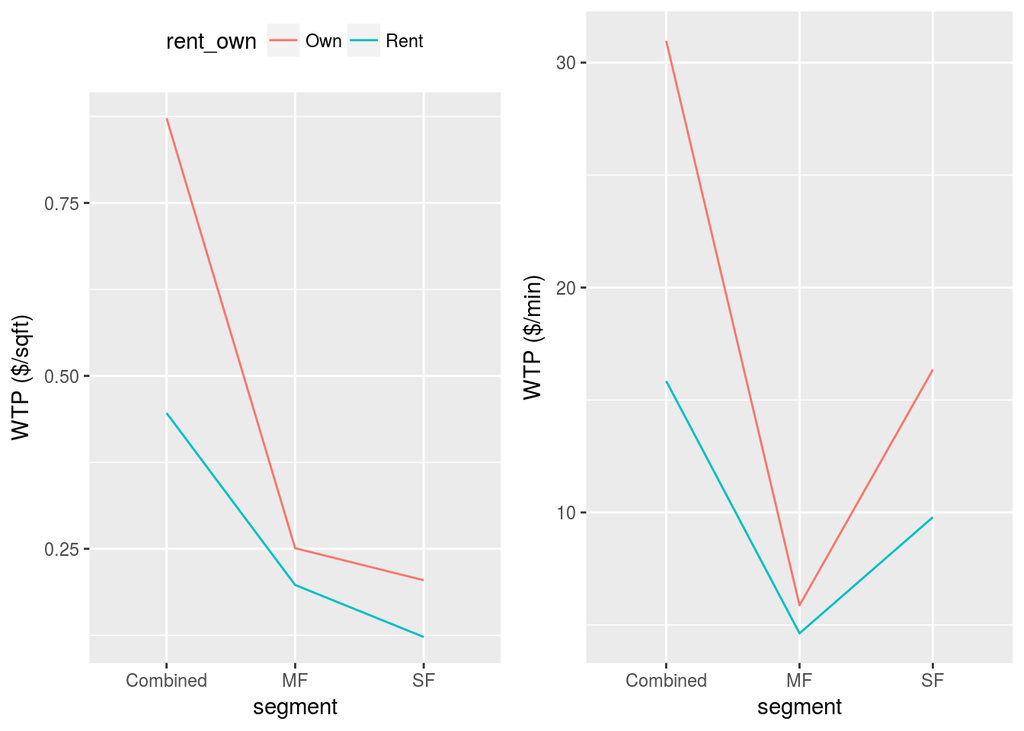

# Coefficients by Age Group (weights=wgt.b)

|  | Combined | 25-64 | 65+ | <25 |
| --- | --- | --- | --- | --- |
|  | (1) | (2) | (3) | (4) |
| 1:(intercept) | 0.083*** | 0.088*** | 0.054* | 0.176 |
|  | (0.012) | (0.014) | (0.028) | (0.114) |
| price | -0.001*** | -0.001*** | -0.001*** | -0.002*** |
|  | (0.00003) | (0.00003) | (0.0001) | (0.0004) |
| own | -0.356*** | -0.193*** | -0.790*** | -0.873*** |
|  | (0.038) | (0.042) | (0.096) | (0.307) |
| commute_time | -0.021*** | -0.021*** | -0.020*** | -0.039*** |
|  | (0.001) | (0.001) | (0.002) | (0.007) |
| size | 0.001*** | 0.001*** | 0.001*** | 0.001*** |
|  | (0.00005) | (0.0001) | (0.0001) | (0.0005) |
| sfd | 0.633*** | 0.794*** | 0.129* | 0.081 |
|  | (0.033) | (0.037) | (0.077) | (0.308) |
| sfa | 0.538*** | 0.624*** | 0.248*** | 0.259 |
|  | (0.019) | (0.021) | (0.043) | (0.181) |
| N1 | 0.309*** | 0.357*** | 0.078 | 1.224*** |
|  | (0.033) | (0.038) | (0.075) | (0.311) |
| N2 | 0.518*** | 0.536*** | 0.418*** | 1.017*** |
|  | (0.023) | (0.026) | (0.053) | (0.214) |
| N3 | 0.156*** | 0.132*** | 0.264*** | 0.217 |
|  | (0.024) | (0.027) | (0.055) | (0.216) |
| price:own | 0.001*** | 0.001*** | 0.001*** | 0.001*** |
|  | (0.00002) | (0.00002) | (0.00005) | (0.0002) |
| Observations | 57,871 | 46,332 | 10,763 | 776 |
| R<sup>2</sup> | 0.126 | 0.138 | 0.095 | 0.216 |
| Log Likelihood | -35,034.130 | -27,673.520 | -6,745.052 | -415.789 |
| *Note:* | *p<0.1; **p<0.05; ***p<0.01 |  |  |  |

# WTPs by Age Group (weights=wgt.b)

| segment | n | Rent $/sqft | Rent $/min | Own $/sqft | Own $/min |
| --- | --- | --- | --- | --- | --- |
| Combined | 57871 | 0.446 | 15.845 | 0.873 | 30.973 |
| 25-64 | 46332 | 0.407 | 15.537 | 0.716 | 27.318 |
| 65+ | 10763 | 0.596 | 17.389 | 1.866 | 54.430 |
| <25 | 776 | 0.562 | 16.734 | 0.925 | 27.568 |

# WTPs by Age Group (weights=wgt.b)

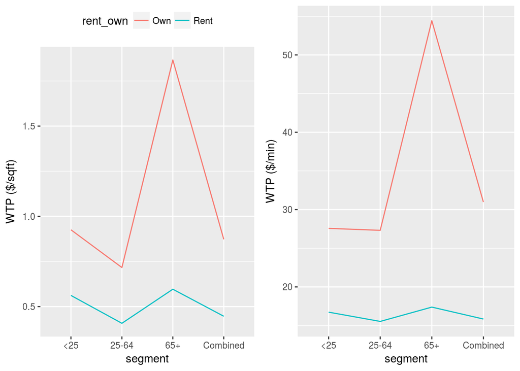

# B.5 Combine SP and RP data

# Assessment of task B.5

- Benefits of combining Stated Preference (SP) data and Revealed Preference (RP) data
    - SP data
    - RP data: surveyee's current residence (housing type, tenure, size, price, etc)
- Difficulties of combining SP data and RP data
    - The unchosen alternative is unknown for surveyee's current residence
    - Residential location choice modleing research with RP only generally uses sampling of (unchosen) alternatives in this case
    - Not aware of application of sampling of alternative when combing RP with SP data
    - If we pursue the route, we can only sample 1 unchosen alternative to have consistent data structure with SP, which is very/too small compared with common practice

# B.6 Neighborhood Choice

# Neighborhood Type Preference

**Neigbhorhood type preference model**

| 2:(intercept) | -0.637 |
| --- | --- |
|  | (0.815) |
| 3:(intercept) | -5.730*** |
|  | (1.082) |
| 4:(intercept) | -2.681*** |
|  | (0.832) |
| same_ngbhtype | 1.692*** |
|  | (0.037) |
| 2:age | -0.002 |
|  | (0.004) |
| 3:age | 0.026*** |
|  | (0.005) |
| 4:age | 0.013*** |
|  | (0.005) |
| 2:hhinc4b.25-49.9k | 0.174 |
|  | (0.173) |
| 3:hhinc4b.25-49.9k | 0.414** |
|  | (0.186) |
| 4:hhinc4b.25-49.9k | 0.946*** |
|  | (0.189) |
| 2:hhinc4b.< 25k | -0.048 |
|  | (0.214) |
| 3:hhinc4b.< 25k | 0.573** |
|  | (0.233) |
| 4:hhinc4b.< 25k | 0.952*** |
|  | (0.233) |
| 2:hhinc4b.50-99.9k | 0.152 |
|  | (0.127) |
| 3:hhinc4b.50-99.9k | 0.271** |
|  | (0.135) |
| 4:hhinc4b.50-99.9k | 0.593*** |

[output cut: 53 more lines]

# Housing Type Preference

**Housing type preference model**

| 2:(intercept) | -5.597*** |
| --- | --- |
|  | (1.115) |
| 3:(intercept) | -5.284*** |
|  | (0.807) |
| same_htype | 1.298*** |
|  | (0.053) |
| 2:age | 0.024*** |
|  | (0.004) |
| 3:age | 0.030*** |
|  | (0.004) |
| 2:hhinc4b.25-49.9k | 0.498*** |
|  | (0.160) |
| 3:hhinc4b.25-49.9k | 0.326* |
|  | (0.170) |
| 2:hhinc4b.< 25k | 0.347* |
|  | (0.208) |
| 3:hhinc4b.< 25k | 0.561*** |
|  | (0.197) |
| 2:hhinc4b.50-99.9k | 0.332*** |
|  | (0.128) |
| 3:hhinc4b.50-99.9k | 0.094 |
|  | (0.137) |
| 2:genderfemale | 1.602 |
|  | (1.056) |
| 3:genderfemale | 0.572 |
|  | (0.708) |
| 2:gendermale | 1.608 |
|  | (1.057) |
| 3:gendermale | 0.854 |
|  | (0.708) |
| 2:genderother | 0.892 |
|  | (1.494) |
| 3:genderother | 1.284 |
|  | (0.981) |
| 2:tenurechrRENT | -0.085 |
|  | (0.140) |
| 3:tenurechrRENT | -0.414*** |
|  | (0.151) |
| 2:npers_lt18 | -0.143 |
|  | (0.106) |
| 3:npers_lt18 | -0.275** |
|  | (0.122) |
| 2:hhsize | -0.050 |
|  | (0.076) |
| 3:hhsize | 0.009 |
|  | (0.080) |
| 2:prf_ngbhtypeRural | -0.321 |
|  | (0.239) |
| 3:prf_ngbhtypeRural | -0.128 |
|  | (0.245) |
| 2:prf_ngbhtypeUrban Central | 2.163*** |
|  | (0.205) |
| 3:prf_ngbhtypeUrban Central | 3.345*** |
|  | (0.189) |
| 2:prf_ngbhtypeUrban Neighborhood | 1.460*** |
|  | (0.162) |
| 3:prf_ngbhtypeUrban Neighborhood | 1.166*** |
|  | (0.175) |
| Observations | 6,526 |
| R<sup>2</sup> | 0.272 |
| Log Likelihood | -2,653.520 |
| *Note:* | *p<0.1; **p<0.05; ***p<0.01 |